# Assignment 2

This assignment is to compare output of KNN to Naive Bayes for predicting whether someone will make more than 50k/year based on features in the data using a binary classifier.

### Packages

```r
library(gmodels)
library(data.table)
library(mltools)
library(caret)
library(class)
```

## Problem 1

### Data Exploration

Import the data set, add the header manually, and validate data is imported correctly. White space needed to be dropped, header set as vector and added, import string columns as character columns, and output was reviewed.

#### Q1:

Done

```r
## Question 1
header = c("age",
           "workclass",
           "fnlwgt",
           "education",
           "educationnum",
           "maritalstatus",
           "occupation",
           "relationship",
           "race",
           "sex",
           "capitalgain",
           "capitalloss",
           "hoursperweek",
           "nativecountry",
           "income")
adults = read.csv("data/adult.data",
                  header=FALSE,
                  col.names=header,
                  strip.white=TRUE)
```

#### Q2:

- Categoric: 10
  - workclass, education, educationnum, maritalstatus, occupation, relationship, race, sex, nativecountry, income (dependent variable)
    - educationnum is an integer value but technically has no measurable distance between values. the difference between 8th and 9th grade is not the same as the distance between 14th and 15th grade. This is also hard to translate between countries.
- Numeric: 5
  - age, fnlwgt, capitalgain, capitalloss, hoursperweek
- Nulls: None
- Missing values:
  - workclass has 1836 missing values, nativecountry has 583 missing values
  - capitalgain has 29849 zero values, capitalloss has 31042 zero values
    - capitalgain and capitalloss may be columns to exclude due to zero values

```r
## Question 2
#str(adults)
### Categoric
summary(adults[,sapply(adults, is.factor)])
```

```
            workclass            education                   maritalstatus
 Private         :22696   HS-grad     :10501   Divorced             : 4443
 Self-emp-not-inc: 2541   Some-college: 7291   Married-AF-spouse    :   23
 Local-gov       : 2093   Bachelors   : 5355   Married-civ-spouse   :14976
 ?               : 1836   Masters     : 1723   Married-spouse-absent:  418
 State-gov       : 1298   Assoc-voc   : 1382   Never-married        :10683
 Self-emp-inc    : 1116   11th        : 1175   Separated            : 1025
 (Other)         :  981   (Other)     : 5134   Widowed              :  993
           occupation           relationship                   race           sex
 Prof-specialty :4140   Husband       :13193   Amer-Indian-Eskimo:  311   Female:10771
 Craft-repair   :4099   Not-in-family : 8305   Asian-Pac-Islander: 1039   Male  :21790
 Exec-managerial:4066   Other-relative:  981   Black             : 3124
 Adm-clerical   :3770   Own-child     : 5068   Other             :  271
 Sales          :3650   Unmarried     : 3446   White             :27816
 Other-service  :3295   Wife          : 1568
 (Other)        :9541
       nativecountry     income
 United-States:29170   <=50K:24720
 Mexico       :  643   >50K : 7841
 ?            :  583
 Philippines  :  198
 Germany      :  137
 Canada       :  121
 (Other)      : 1709
```

```r
### Numeric
summary(adults[, !sapply(adults, is.factor)])
```

```
      age            fnlwgt         educationnum    capitalgain     capitalloss
 Min.   :17.00   Min.   :  12285   Min.   : 1.00   Min.   :    0   Min.   :   0.0
 1st Qu.:28.00   1st Qu.: 117827   1st Qu.: 9.00   1st Qu.:    0   1st Qu.:   0.0
 Median :37.00   Median : 178356   Median :10.00   Median :    0   Median :   0.0
 Mean   :38.58   Mean   : 189778   Mean   :10.08   Mean   : 1078   Mean   :  87.3
 3rd Qu.:48.00   3rd Qu.: 237051   3rd Qu.:12.00   3rd Qu.:    0   3rd Qu.:   0.0
 Max.   :90.00   Max.   :1484705   Max.   :16.00   Max.   :99999   Max.   :4356.0
  hoursperweek
 Min.   : 1.00
 1st Qu.:40.00
 Median :40.00
 Mean   :40.44
 3rd Qu.:45.00
 Max.   :99.00
```

```r
### NA values
# colSums(is.na(adults))
# apply(is.na(adults), 2, which)
colSums(adults == 0 | is.na(adults))
```

```
          age     workclass        fnlwgt     education  educationnum maritalstatus
            0             0             0             0             0             0
   occupation  relationship          race           sex   capitalgain   capitalloss
            0             0             0             0         29849         31042
 hoursperweek nativecountry        income
            0             0             0
```

#### Q3:

The data is skewed towards incomes less than 50k. This distribution is ~5% different from the 2016 US Census Bureau population survey.

```r
prop.table(table(adults$income))
```

```
    <=50K      >50K
0.7591904 0.2408096
```

#### Q4:

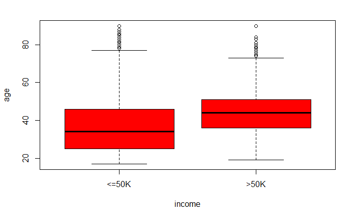

```r
plot(adults$age~adults$income, col="red",
     xlab="income", ylab="age")
```

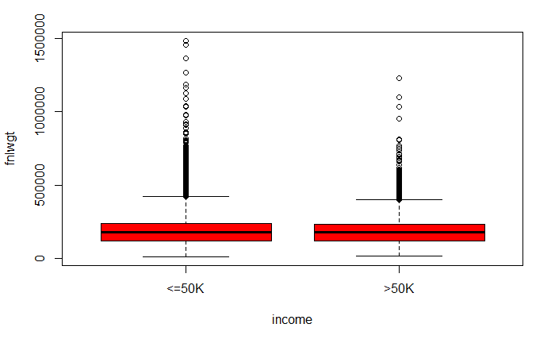

```r
plot(adults$fnlwgt~adults$income, col="red",
     xlab="income", ylab="fnlwgt")
```

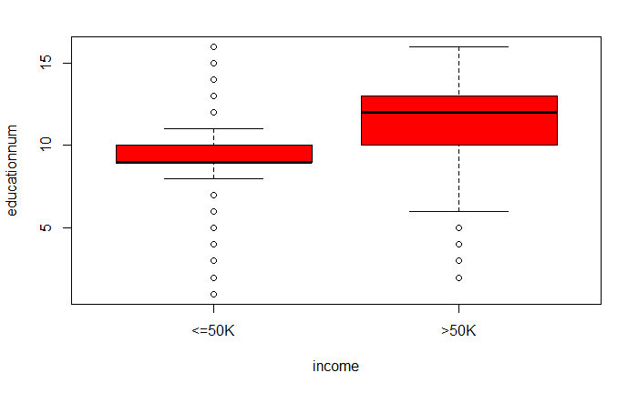

```r
plot(adults$educationnum~adults$income, col="red",
     xlab="income", ylab="educationnum")
```

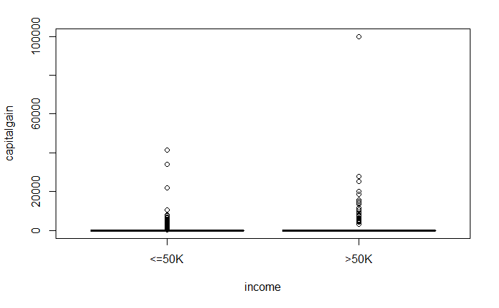

```r
plot(adults$capitalgain~adults$income, col="red",
     xlab="income", ylab="capitalgain")
```

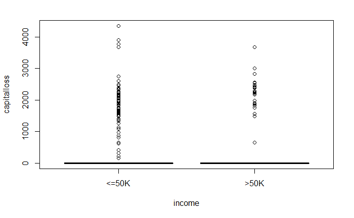

```r
plot(adults$capitalloss~adults$income, col="red",
     xlab="income", ylab="capitalloss")
```

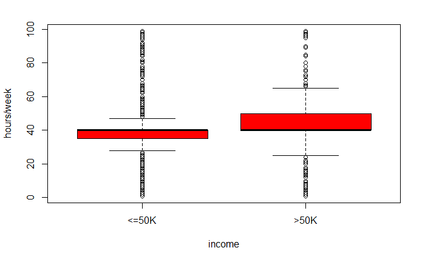

```r
plot(adults$hoursperweek~adults$income, col="red",
     xlab="income", ylab="hours/week")
```

```r
options(scipen=999)
table(adults$income, adults$workclass)
```

```
            ? Federal-gov Local-gov Never-worked Private Self-emp-inc Self-emp-not-inc
  <=50K  1645         589      1476            7   17733          494             1817
  >50K    191         371       617            0    4963          622              724

        State-gov Without-pay
  <=50K       945          14
  >50K        353           0
```

```r
table(adults$income, adults$education)
```

```
        10th 11th 12th 1st-4th 5th-6th 7th-8th  9th Assoc-acdm Assoc-voc Bachelors Doctorate
  <=50K  871 1115  400     162     317     606  487        802      1021      3134       107
  >50K    62   60   33       6      16      40   27        265       361      2221       306

        HS-grad Masters Preschool Prof-school Some-college
  <=50K    8826     764        51         153         5904
  >50K     1675     959         0         423         1387
```

```r
table(adults$income, adults$maritalstatus)
```

```
        Divorced Married-AF-spouse Married-civ-spouse Married-spouse-absent Never-married
  <=50K     3980                13               8284                   384         10192
  >50K       463                10               6692                    34           491

        Separated Widowed
  <=50K       959     908
  >50K         66      85
```

```r
table(adults$income, adults$occupation)
```

```
           ? Adm-clerical Armed-Forces Craft-repair Exec-managerial Farming-fishing
  <=50K 1652         3263            8         3170            2098             879
  >50K   191          507            1          929            1968             115

        Handlers-cleaners Machine-op-inspct Other-service Priv-house-serv Prof-specialty
  <=50K              1284              1752          3158             148           2281
  >50K                 86               250           137               1           1859

        Protective-serv Sales Tech-support Transport-moving
  <=50K             438  2667          645             1277
  >50K              211   983          283              320
```

```r
table(adults$income, adults$relationship)
```

```
        Husband Not-in-family Other-relative Own-child Unmarried Wife
  <=50K    7275          7449            944      5001      3228  823
  >50K     5918           856             37        67       218  745
```

```r
table(adults$income, adults$race)
```

```
        Amer-Indian-Eskimo Asian-Pac-Islander Black Other White
  <=50K                275                763  2737   246 20699
  >50K                  36                276   387    25  7117
```

```r
table(adults$income, adults$sex)
```

```
        Female  Male
  <=50K   9592 15128
  >50K    1179  6662
```

```r
table(adults$income, adults$nativecountry)
```

```
            ? Cambodia Canada China Columbia  Cuba Dominican-Republic Ecuador El-Salvador
  <=50K   437       12     82    55       57    70                 68      24          97
  >50K    146        7     39    20        2    25                  2       4           9

        England France Germany Greece Guatemala Haiti Holand-Netherlands Honduras  Hong
  <=50K      60     17      93     21        61    40                  1       12    14
  >50K       30     12      44      8         3     4                  0        1     6

        Hungary India  Iran Ireland Italy Jamaica Japan  Laos Mexico Nicaragua
  <=50K      10    60    25      19    48      71    38    16    610        32
  >50K        3    40    18       5    25      10    24     2     33         2

        Outlying-US(Guam-USVI-etc)  Peru Philippines Poland Portugal Puerto-Rico Scotland
  <=50K                         14    29         137     48       33         102        9
  >50K                           0     2          61     12        4          12        3

        South Taiwan Thailand Trinadad&Tobago United-States Vietnam Yugoslavia
  <=50K    64     31       15              17         21999      62         10
  >50K     16     20        3               2          7171       5          6
```

```r
#CrossTable(x=adults$income, y=adults$workclass)
chisq.test(adults$income, adults$workclass)
```

```
Chi-squared approximation may be incorrect
```

```
    Pearson's Chi-squared test

data:  adults$income and adults$workclass
X-squared = 1045.7, df = 8, p-value < 0.00000000000000022
```

```r
#CrossTable(x=adults$income, y=adults$education)
chisq.test(adults$income, adults$education)
```

```
    Pearson's Chi-squared test

data:  adults$income and adults$education
X-squared = 4429.7, df = 15, p-value < 0.00000000000000022
```

```r
#CrossTable(x=adults$income, y=adults$maritalstatus)
chisq.test(adults$income, adults$maritalstatus)
```

```
    Pearson's Chi-squared test

data:  adults$income and adults$maritalstatus
X-squared = 6517.7, df = 6, p-value < 0.00000000000000022
```

```r
#CrossTable(x=adults$income, y=adults$occupation)
chisq.test(adults$income, adults$occupation)
```

```
Chi-squared approximation may be incorrect
```

```
    Pearson's Chi-squared test

data:  adults$income and adults$occupation
X-squared = 4032, df = 14, p-value < 0.00000000000000022
```

```r
#CrossTable(x=adults$income, y=adults$relationship)
chisq.test(adults$income, adults$relationship)
```

```
    Pearson's Chi-squared test

data:  adults$income and adults$relationship
X-squared = 6699.1, df = 5, p-value < 0.00000000000000022
```

```r
#CrossTable(x=adults$income, y=adults$race)
chisq.test(adults$income, adults$race)
```

```
    Pearson's Chi-squared test

data:  adults$income and adults$race
X-squared = 330.92, df = 4, p-value < 0.00000000000000022
```

```r
#CrossTable(x=adults$income, y=adults$sex)
chisq.test(adults$income, adults$sex)
```

```
    Pearson's Chi-squared test with Yates' continuity correction

data:  adults$income and adults$sex
X-squared = 1517.8, df = 1, p-value < 0.00000000000000022
```

```r
#CrossTable(x=adults$income, y=adults$nativecountry)
chisq.test(adults$income, adults$nativecountry)
```

```
Chi-squared approximation may be incorrect
```

```
    Pearson's Chi-squared test

data:  adults$income and adults$nativecountry
X-squared = 317.23, df = 41, p-value < 0.00000000000000022
```

```r
unique(adults[c("education","educationnum")])
```

|  | education | educationnum |
| --- | --- | --- |
| 1 | Bachelors | 13 |
| 3 | HS-grad | 9 |
| 4 | 11th | 7 |
| 6 | Masters | 14 |
| 7 | 9th | 5 |
| 11 | Some-college | 10 |
| 14 | Assoc-acdm | 12 |
| 15 | Assoc-voc | 11 |
| 16 | 7th-8th | 4 |
| 21 | Doctorate | 16 |

[output cut: 6 more lines]

```r
adults$educationnum <- NULL
adults$fnlwgt <- NULL
#adults$capitalgain <- NULL
#adults$capitalloss <- NULL
```

### Data Preparation

#### Q5:

Replace ?s

```r
adults[adults == "?"] <- NA
summary(adults[,sapply(adults, is.factor)])
```

```
            workclass            education                   maritalstatus
 Private         :22696   HS-grad     :10501   Divorced             : 4443
 Self-emp-not-inc: 2541   Some-college: 7291   Married-AF-spouse    :   23
 Local-gov       : 2093   Bachelors   : 5355   Married-civ-spouse   :14976
 State-gov       : 1298   Masters     : 1723   Married-spouse-absent:  418
 Self-emp-inc    : 1116   Assoc-voc   : 1382   Never-married        :10683
 (Other)         :  981   11th        : 1175   Separated            : 1025
 NA's            : 1836   (Other)     : 5134   Widowed              :  993
           occupation            relationship                   race           sex
 Prof-specialty : 4140   Husband       :13193   Amer-Indian-Eskimo:  311   Female:10771
 Craft-repair   : 4099   Not-in-family : 8305   Asian-Pac-Islander: 1039   Male  :21790
 Exec-managerial: 4066   Other-relative:  981   Black             : 3124
 Adm-clerical   : 3770   Own-child     : 5068   Other             :  271
 Sales          : 3650   Unmarried     : 3446   White             :27816
 (Other)        :10993   Wife          : 1568
 NA's           : 1843
       nativecountry     income
 United-States:29170   <=50K:24720
 Mexico       :  643   >50K : 7841
 Philippines  :  198
 Germany      :  137
 Canada       :  121
 (Other)      : 1709
 NA's         :  583
```

#### Q6:

Used earlier for data exploration but:

- workclass - 1836
- occupation - 1843
- nativecountry - 583

```r
colSums(is.na(adults))
```

```
          age     workclass     education maritalstatus    occupation  relationship
            0          1836             0             0          1843             0
         race           sex   capitalgain   capitalloss  hoursperweek nativecountry
            0             0             0             0             0           583
       income
            0
```

#### Q7:

There were no null values in any numeric columns, null values in 3 categoric columns were replaced with the mode/majority value of the respective column.

```r
wc = table(adults$workclass)
adults$workclass[is.na(adults$workclass)] <- names(wc[wc == max(wc)])
oc = table(adults$occupation)
adults$occupation[is.na(adults$occupation)] <- names(oc[oc == max(oc)])
nc = table(adults$nativecountry)
adults$nativecountry[is.na(adults$nativecountry)] <- names(nc[nc == max(nc)])
colSums(is.na(adults))
```

```
          age     workclass     education maritalstatus    occupation  relationship
            0             0             0             0             0             0
         race           sex   capitalgain   capitalloss  hoursperweek nativecountry
            0             0             0             0             0             0
       income
            0
```

#### Q8:

One Hot encoding to pivot category levels into binary columns. Assigned back to data frame.

```r
adults_labels <- adults$income
adults$income <- NULL
adults_dt <- data.table(adults)
adults_dt_oh <- one_hot(adults_dt, dropUnusedLevels=TRUE, dropCols=TRUE)
adults_dt <- as.data.frame(adults_dt_oh)
adults_dt$income <- adults_labels
```

#### Q9:

Set seed, but it needs set in each code block because of notebook design.

```r
set.seed(1)
```

#### Q10:

Min-Max Scaling or Normalize numeric features

```r
normalize <- function(x) {
  return ((x-min(x)) / (max(x)-min(x)))
}
adults_n <- adults_dt
#adults_n[c("age","capitalgain","capitalloss","hoursperweek")] <-
#  sapply(adults[c("age","capitalgain","capitalloss","hoursperweek")],normalize)
adults_n[c("age","hoursperweek")] <-
  sapply(adults[c("age","hoursperweek")],normalize)
summary(adults_n[c("age","hoursperweek")])
```

```
      age          hoursperweek
 Min.   :0.0000   Min.   :0.0000
 1st Qu.:0.1507   1st Qu.:0.3980
 Median :0.2740   Median :0.3980
 Mean   :0.2956   Mean   :0.4024
 3rd Qu.:0.4247   3rd Qu.:0.4490
 Max.   :1.0000   Max.   :1.0000
```

#### Q11:

Randomize the order of the data

```r
set.seed(1)
adults_n <- adults_n[sample(nrow(adults_n), replace=FALSE), ]
adults_n_labels <- adults_n$income
adults_n$income <- NULL
```

#### Q12:

```r
set.seed(1)
## K fold function
knn_fold <- function(features, target, fold, k) {
  train=features[-fold, ]
  validation=features[fold, ]
  train_labels=target[-fold]
  validation_labels=target[fold]
  validation_preds=knn(train, validation, train_labels, k=k)
  t=table(validation_labels, validation_preds)
  error=(t[1,2]+t[2,1]) / (t[1,1]+t[1,2]+t[2,1]+t[2,2])
  return(error)
}
## Crossvalidation function to create folds and pass necessary
crossValidationError <- function(features, target, k) {
  folds=createFolds(target, k=10)
  errors=sapply(folds, knn_fold, features=features, target=target, k=k)
  return(mean(errors))
}
crossValidationError(adults_n, adults_n_labels, k=5)
```

```
[1] 0.1443137
```

#### Q13:

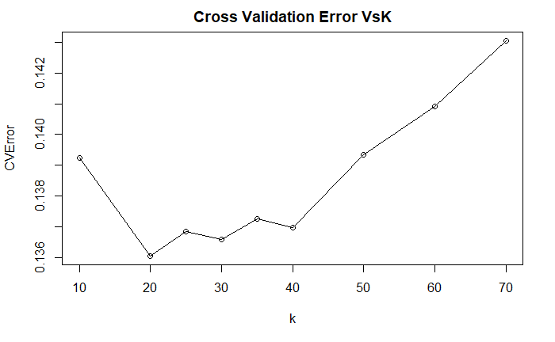

```r
set.seed(1)
n <- nrow(adults_n)
#ks <- c(20, 50, 55, 57, 60, 100)
ks <- c(10,20,25, 30,35, 40, 50, 60, 70)
#ks <- c(21,22,23,24)
errors <- sapply(ks,
                 crossValidationError,
                 features=adults_n,
                 target=adults_n_labels)
plot(errors~ks, main="Cross Validation Error VsK",
     xlab="k",
     ylab="CVError")
lines(errors~ks)
```

#### Q14:

```r
set.seed(1)
## K fold function
knn_fold_FPR_FNR <- function(features, target, fold, k) {
  train=features[-fold, ]
  validation=features[fold, ]
  train_labels=target[-fold]
  validation_labels=target[fold]
  validation_preds=knn(train, validation, train_labels, k=k)
  t=table(validation_labels, validation_preds)
  # Column 1 is <=50K and Column 2 is >50K
  FPR=t[1,2]/(t[1,2]+t[1,1]) # Actually >50K but predicted as <=50K
  FNR=t[2,1]/(t[2,1]+t[2,2]) # Actually <=50K but predicted as >50K
  OVR=(t[1,2]+t[2,1]) / (t[1,1]+t[1,2]+t[2,1]+t[2,2])
  return(c(">50k error"=FPR,"<=50K error"=FNR, "Overall"=OVR))
}
## Crossvalidation function to create folds and pass necessary
crossValidationError_FPR_FNR <- function(features, target, k) {
  folds=createFolds(target, k=10)
  errors=sapply(folds, knn_fold_FPR_FNR, features=features, target=target, k=k)
  return(rowMeans(errors))
}
crossValidationError_FPR_FNR(adults_n, adults_n_labels, k=5)
```

```
 >50k error <=50K error     Overall
 0.08228155  0.33988090  0.14431369
```

#### Q15:

The training error would be ~24% because all >50K would be classified incorrect and all <=50K would be correct. The total proportion is approximately 24%. This alone indicates it would be better overall to use KNN versus majority classifier. Looking more specifically at the FPR and FNR for majority classifier and KNN shows it is indeed better to use KNN. The total error being ~10% less than the majority classifier error.

#### Q16:

The majority classifier’s FPR is 0% while the FNR is 100% and this leads to an overall error of ~24%. This occurs if <=50K is considered the negative class and when all are classified as <=50K then no data points are predicted as the positive class of >50K. Meanwhile, all of the >50K are classified wrong and that will produce a FNR of 100%. The KNN model had an error of ~8% of >50K (FPR) and ~34% of <=50K (FNR) with an overall error of ~14.4%. The cost to have an improved FNR is the 8% increase in the FPR.

## Problem 2

#### Q1:

```r
set.seed(1)
```

#### Q2:

educationnum and fnlwgt were decided to be removed earlier and that should still work.

```r
str(adults)
```

```
'data.frame':   32561 obs. of  12 variables:
 $ age          : int  39 50 38 53 28 37 49 52 31 42 ...
 $ workclass    : Factor w/ 9 levels "?","Federal-gov",..: 8 7 5 5 5 5 5 7 5 5 ...
 $ education    : Factor w/ 16 levels "10th","11th",..: 10 10 12 2 10 13 7 12 13 10 ...
 $ maritalstatus: Factor w/ 7 levels "Divorced","Married-AF-spouse",..: 5 3 1 3 3 3 4 3 5 3 ...
 $ occupation   : Factor w/ 15 levels "?","Adm-clerical",..: 2 5 7 7 11 5 9 5 11 5 ...
 $ relationship : Factor w/ 6 levels "Husband","Not-in-family",..: 2 1 2 1 6 6 2 1 2 1 ...
 $ race         : Factor w/ 5 levels "Amer-Indian-Eskimo",..: 5 5 5 3 3 5 3 5 5 5 ...
 $ sex          : Factor w/ 2 levels "Female","Male": 2 2 2 2 1 1 1 2 1 2 ...
 $ capitalgain  : int  2174 0 0 0 0 0 0 0 14084 5178 ...
 $ capitalloss  : int  0 0 0 0 0 0 0 0 0 0 ...
 $ hoursperweek : int  40 13 40 40 40 40 16 45 50 40 ...
 $ nativecountry: Factor w/ 42 levels "?","Cambodia",..: 40 40 40 40 6 40 24 40 40 40 ...
```

#### Q3:

Overall error is ~18%,the FPR is ~5.6%, and the FNR is ~58.5%.

```r
library(e1071)
set.seed(1)
smp_size <- floor(.85 * nrow(adults))
smp_size_plus <- smp_size+1
pop_size <- as.numeric(nrow(adults))
adults_train <- adults[1:smp_size,]
adults_test <- adults[smp_size_plus:pop_size,]
adults_train_labels <- adults_labels[1:smp_size]
adults_test_labels <- adults_labels[smp_size_plus:pop_size]
# Non K-fold method
adults_classifier <- naiveBayes(adults_train, adults_train_labels)
adults_test_pred <- predict(adults_classifier, adults_test)
#CrossTable(adults_test_pred, adults_test_labels, prop.chisq=FALSE, prop.t=FALSE,
#           dnn=c("predicted","actual"))
# K-fold method
naiveBayes_fold <- function(fold, features, target, laplace=0) {
  train = features[-fold,]
  validation = features[fold,]
  train_labels = target[-fold]
  validation_labels = target[fold]
  NaiveBayes_model = naiveBayes(train,train_labels,laplace=laplace)
  validation_preds = predict(NaiveBayes_model, validation)
  t = table(validation_labels,validation_preds)
  FPR = t[1,2]/(t[1,2]+t[1,1]) # Actually >50K but predicted <=50K
  FNR = t[2,1]/(t[2,1]+t[2,2])# Actually <=50K but predicted >50K
  OVR=(t[1,2]+t[2,1]) / (t[1,1]+t[1,2]+t[2,1]+t[2,2])
  return (c(">50K error"=FPR,"<=50K error"=FNR, "Overall"=OVR))
}
crossValidationError_nb <- function(features, target, laplace=0, n_folds) {
  folds = createFolds(target,k=n_folds)
  errors = sapply(folds, naiveBayes_fold, features=features, target=target,
               laplace=laplace)
  return(rowMeans(errors))
}
errors <- crossValidationError_nb(features=rbind(adults_train, adults_test),
                               target=adults_labels,
                               n_folds=5)
print(errors)
```

```
 >50K error <=50K error     Overall
 0.05622977  0.58500393  0.18356342
```

#### Q5:

The FPR and FNR for the majority classifier are the same as discussed in problem #1. The Gaussian Naive Bayes FPR was ~5.6% and the FNR was ~58.5%. This is better than the FNR of majority classifier at the cost of the FPR but the overall is ~6% better.